# Load Data & Initial Exploration

```python
import pandas as pd
import numpy as np
import matplotlib.pyplot as plt
import seaborn as sns

star_wars = pd.read_csv('star_wars.csv', encoding='ISO-8859-1')
```

```python
star_wars.head(10)
```

|  | RespondentID | Have you seen any of the 6 films in the Star Wars franchise? | Do you consider yourself to be a fan of the Star Wars film franchise? | Which of the following Star Wars films have you seen? Please select all that apply. | Unnamed: 4 | Unnamed: 5 | Unnamed: 6 | Unnamed: 7 | Unnamed: 8 | Please rank the Star Wars films in order of preference with 1 being your favorite film in the franchise and 6 being your least favorite film. | ... | Unnamed: 28 | Which character shot first? | Are you familiar with the Expanded Universe? | Do you consider yourself to be a fan of the Expanded Universe? | Do you consider yourself to be a fan of the Star Trek franchise? | Gender | Age | Household Income | Education | Location (Census Region) |
| --- | --- | --- | --- | --- | --- | --- | --- | --- | --- | --- | --- | --- | --- | --- | --- | --- | --- | --- | --- | --- | --- |
| 0 | 3292879998 | Yes | Yes | Star Wars: Episode I The Phantom Menace | Star Wars: Episode II Attack of the Clones | Star Wars: Episode III Revenge of the Sith | Star Wars: Episode IV A New Hope | Star Wars: Episode V The Empire Strikes Back | Star Wars: Episode VI Return of the Jedi | 3.0 | ... | Very favorably | I don't understand this question | Yes | No | No | Male | 18-29 | NaN | High school degree | South Atlantic |
| 1 | 3292879538 | No | NaN | NaN | NaN | NaN | NaN | NaN | NaN | NaN | ... | NaN | NaN | NaN | NaN | Yes | Male | 18-29 | $0 - $24,999 | Bachelor degree | West South Central |
| 2 | 3292765271 | Yes | No | Star Wars: Episode I The Phantom Menace | Star Wars: Episode II Attack of the Clones | Star Wars: Episode III Revenge of the Sith | NaN | NaN | NaN | 1.0 | ... | Unfamiliar (N/A) | I don't understand this question | No | NaN | No | Male | 18-29 | $0 - $24,999 | High school degree | West North Central |
| 3 | 3292763116 | Yes | Yes | Star Wars: Episode I The Phantom Menace | Star Wars: Episode II Attack of the Clones | Star Wars: Episode III Revenge of the Sith | Star Wars: Episode IV A New Hope | Star Wars: Episode V The Empire Strikes Back | Star Wars: Episode VI Return of the Jedi | 5.0 | ... | Very favorably | I don't understand this question | No | NaN | Yes | Male | 18-29 | $100,000 - $149,999 | Some college or Associate degree | West North Central |
| 4 | 3292731220 | Yes | Yes | Star Wars: Episode I The Phantom Menace | Star Wars: Episode II Attack of the Clones | Star Wars: Episode III Revenge of the Sith | Star Wars: Episode IV A New Hope | Star Wars: Episode V The Empire Strikes Back | Star Wars: Episode VI Return of the Jedi | 5.0 | ... | Somewhat favorably | Greedo | Yes | No | No | Male | 18-29 | $100,000 - $149,999 | Some college or Associate degree | West North Central |
| 5 | 3292719380 | Yes | Yes | Star Wars: Episode I The Phantom Menace | Star Wars: Episode II Attack of the Clones | Star Wars: Episode III Revenge of the Sith | Star Wars: Episode IV A New Hope | Star Wars: Episode V The Empire Strikes Back | Star Wars: Episode VI Return of the Jedi | 1.0 | ... | Very favorably | Han | Yes | No | Yes | Male | 18-29 | $25,000 - $49,999 | Bachelor degree | Middle Atlantic |
| 6 | 3292684787 | Yes | Yes | Star Wars: Episode I The Phantom Menace | Star Wars: Episode II Attack of the Clones | Star Wars: Episode III Revenge of the Sith | Star Wars: Episode IV A New Hope | Star Wars: Episode V The Empire Strikes Back | Star Wars: Episode VI Return of the Jedi | 6.0 | ... | Very favorably | Han | Yes | No | No | Male | 18-29 | NaN | High school degree | East North Central |
| 7 | 3292663732 | Yes | Yes | Star Wars: Episode I The Phantom Menace | Star Wars: Episode II Attack of the Clones | Star Wars: Episode III Revenge of the Sith | Star Wars: Episode IV A New Hope | Star Wars: Episode V The Empire Strikes Back | Star Wars: Episode VI Return of the Jedi | 4.0 | ... | Very favorably | Han | No | NaN | Yes | Male | 18-29 | NaN | High school degree | South Atlantic |
| 8 | 3292654043 | Yes | Yes | Star Wars: Episode I The Phantom Menace | Star Wars: Episode II Attack of the Clones | Star Wars: Episode III Revenge of the Sith | Star Wars: Episode IV A New Hope | Star Wars: Episode V The Empire Strikes Back | Star Wars: Episode VI Return of the Jedi | 5.0 | ... | Somewhat favorably | Han | No | NaN | No | Male | 18-29 | $0 - $24,999 | Some college or Associate degree | South Atlantic |
| 9 | 3292640424 | Yes | No | NaN | Star Wars: Episode II Attack of the Clones | NaN | NaN | NaN | NaN | 1.0 | ... | Very favorably | I don't understand this question | No | NaN | No | Male | 18-29 | $25,000 - $49,999 | Some college or Associate degree | Pacific |

10 rows × 38 columns

```python
star_wars.columns
```

```
Index(['RespondentID',
       'Have you seen any of the 6 films in the Star Wars franchise?',
       'Do you consider yourself to be a fan of the Star Wars film franchise?',
       'Which of the following Star Wars films have you seen? Please select all that apply.',
       'Unnamed: 4', 'Unnamed: 5', 'Unnamed: 6', 'Unnamed: 7', 'Unnamed: 8',
       'Please rank the Star Wars films in order of preference with 1 being your favorite film in the franchise and 6 being your least favorite film.',
       'Unnamed: 10', 'Unnamed: 11', 'Unnamed: 12', 'Unnamed: 13',
       'Unnamed: 14',
       'Please state whether you view the following characters favorably, unfavorably, or are unfamiliar with him/her.',
       'Unnamed: 16', 'Unnamed: 17', 'Unnamed: 18', 'Unnamed: 19',
       'Unnamed: 20', 'Unnamed: 21', 'Unnamed: 22', 'Unnamed: 23',
       'Unnamed: 24', 'Unnamed: 25', 'Unnamed: 26', 'Unnamed: 27',
       'Unnamed: 28', 'Which character shot first?',
       'Are you familiar with the Expanded Universe?',
       'Do you consider yourself to be a fan of the Expanded Universe?',
       'Do you consider yourself to be a fan of the Star Trek franchise?',
       'Gender', 'Age', 'Household Income', 'Education',
       'Location (Census Region)'],
      dtype='object')
```

```python
star_wars['Have you seen any of the 6 films in the Star Wars franchise?'].value_counts(dropna=False)
```

```
Have you seen any of the 6 films in the Star Wars franchise?
Yes    936
No     250
Name: count, dtype: int64
```

```python
star_wars['Do you consider yourself to be a fan of the Star Wars film franchise?'].value_counts(dropna=False)
```

```
Do you consider yourself to be a fan of the Star Wars film franchise?
Yes    552
NaN    350
No     284
Name: count, dtype: int64
```

# Convert Columns to Boolean

```python
# Convert 'Have you seen any of the 6 films in the Star Wars franchise?' column

target_cols = [
    'Have you seen any of the 6 films in the Star Wars franchise?',
    'Do you consider yourself to be a fan of the Star Wars film franchise?',
]

# Change values from 'Yes'/'No' to True/False
for target_col in target_cols:
    star_wars[target_col] = star_wars[target_col].map({'Yes': True, 'No': False})
```

```python
star_wars['Have you seen any of the 6 films in the Star Wars franchise?'].value_counts(dropna=False)
```

```
Have you seen any of the 6 films in the Star Wars franchise?
True     936
False    250
Name: count, dtype: int64
```

```python
star_wars['Do you consider yourself to be a fan of the Star Wars film franchise?'].value_counts(dropna=False)
```

```
Do you consider yourself to be a fan of the Star Wars film franchise?
True     552
NaN      350
False    284
Name: count, dtype: int64
```

# Clean Checkbox Columns

```python
# Check entry values in each column
watched_cols = star_wars.columns[3:9]

for col in watched_cols:
    print(star_wars[col].value_counts(dropna=False))
```

```
Which of the following Star Wars films have you seen? Please select all that apply.
Star Wars: Episode I  The Phantom Menace    673
NaN                                         513
Name: count, dtype: int64
Unnamed: 4
NaN                                            615
Star Wars: Episode II  Attack of the Clones    571
Name: count, dtype: int64
Unnamed: 5
NaN                                            636
Star Wars: Episode III  Revenge of the Sith    550
Name: count, dtype: int64
Unnamed: 6
Star Wars: Episode IV  A New Hope    607
NaN                                  579
Name: count, dtype: int64
Unnamed: 7
Star Wars: Episode V The Empire Strikes Back    758
NaN                                             428
Name: count, dtype: int64
Unnamed: 8
Star Wars: Episode VI Return of the Jedi    738
NaN                                         448
Name: count, dtype: int64
```

```python
# Convert watched columns to boolean
movie_names = [
    'Star Wars: Episode I  The Phantom Menace',
    'Star Wars: Episode II  Attack of the Clones',
    'Star Wars: Episode III  Revenge of the Sith',
    'Star Wars: Episode IV  A New Hope',
    'Star Wars: Episode V The Empire Strikes Back',
    'Star Wars: Episode VI Return of the Jedi',
]

for i in range(len(watched_cols)):
    star_wars[watched_cols[i]] = star_wars[watched_cols[i]].map({movie_names[i]: True, np.nan: False})
```

```python
for col in watched_cols:
    print(star_wars[col].value_counts(dropna=False))
```

```
Which of the following Star Wars films have you seen? Please select all that apply.
True     673
False    513
Name: count, dtype: int64
Unnamed: 4
False    615
True     571
Name: count, dtype: int64
Unnamed: 5
False    636
True     550
Name: count, dtype: int64
Unnamed: 6
True     607
False    579
Name: count, dtype: int64
Unnamed: 7
True     758
False    428
Name: count, dtype: int64
Unnamed: 8
True     738
False    448
Name: count, dtype: int64
```

```python
# Rename column names to a more readable format
for i in range(len(watched_cols)):
    star_wars.rename(columns={watched_cols[i]: f'seen_{i+1}'}, inplace=True)
```

```python
star_wars.head()
```

|  | RespondentID | Have you seen any of the 6 films in the Star Wars franchise? | Do you consider yourself to be a fan of the Star Wars film franchise? | seen_1 | seen_2 | seen_3 | seen_4 | seen_5 | seen_6 | Please rank the Star Wars films in order of preference with 1 being your favorite film in the franchise and 6 being your least favorite film. | ... | Unnamed: 28 | Which character shot first? | Are you familiar with the Expanded Universe? | Do you consider yourself to be a fan of the Expanded Universe? | Do you consider yourself to be a fan of the Star Trek franchise? | Gender | Age | Household Income | Education | Location (Census Region) |
| --- | --- | --- | --- | --- | --- | --- | --- | --- | --- | --- | --- | --- | --- | --- | --- | --- | --- | --- | --- | --- | --- |
| 0 | 3292879998 | True | True | True | True | True | True | True | True | 3.0 | ... | Very favorably | I don't understand this question | Yes | No | No | Male | 18-29 | NaN | High school degree | South Atlantic |
| 1 | 3292879538 | False | NaN | False | False | False | False | False | False | NaN | ... | NaN | NaN | NaN | NaN | Yes | Male | 18-29 | $0 - $24,999 | Bachelor degree | West South Central |
| 2 | 3292765271 | True | False | True | True | True | False | False | False | 1.0 | ... | Unfamiliar (N/A) | I don't understand this question | No | NaN | No | Male | 18-29 | $0 - $24,999 | High school degree | West North Central |
| 3 | 3292763116 | True | True | True | True | True | True | True | True | 5.0 | ... | Very favorably | I don't understand this question | No | NaN | Yes | Male | 18-29 | $100,000 - $149,999 | Some college or Associate degree | West North Central |
| 4 | 3292731220 | True | True | True | True | True | True | True | True | 5.0 | ... | Somewhat favorably | Greedo | Yes | No | No | Male | 18-29 | $100,000 - $149,999 | Some college or Associate degree | West North Central |

5 rows × 38 columns

# Clean Ranking Columns

```python
# Change type to float
ranking_cols = star_wars.columns[9:15]

star_wars[ranking_cols] = star_wars[ranking_cols].astype(float)

# Rename columns into clearer format
for i in range(len(ranking_cols)):
    star_wars.rename(columns={ranking_cols[i]: f'ranking_{i+1}'}, inplace=True)
```

```python
star_wars.iloc[:, 9:15].head()
```

|  | ranking_1 | ranking_2 | ranking_3 | ranking_4 | ranking_5 | ranking_6 |
| --- | --- | --- | --- | --- | --- | --- |
| 0 | 3.0 | 2.0 | 1.0 | 4.0 | 5.0 | 6.0 |
| 1 | NaN | NaN | NaN | NaN | NaN | NaN |
| 2 | 1.0 | 2.0 | 3.0 | 4.0 | 5.0 | 6.0 |
| 3 | 5.0 | 6.0 | 1.0 | 2.0 | 4.0 | 3.0 |
| 4 | 5.0 | 4.0 | 6.0 | 2.0 | 1.0 | 3.0 |

# Find Highest Ranked Movie

[figure not shown]

```python
# Plot rankings on a bar graph

ranking_cols_new = ['ranking_1', 'ranking_2', 'ranking_3', 'ranking_4', 'ranking_5', 'ranking_6']

star_wars[ranking_cols_new].mean().plot.bar()

plt.title('Star Wars Movie Ranking Out of 6\n(Lower Rank is Better)')

plt.xticks(rotation=45)

plt.ylim(5, 1)
plt.yticks([1, 2, 3, 4, 5, 6])

plt.tick_params(bottom=False, left=False)

plt.tight_layout()
sns.despine()

plt.savefig('visualizations/movie_rankings')
```

## Work Done:

- Cleaned the data (boolean columns)
- Renamed column names to more readable and interpretable naming schemes
- Plotted the rankings per movie

## Insights:

- The original trilogy fairs better in overall average rankings across this survey (Star Wars Episode IV through VI)
- Sequel trilogy decreses in overall ranking with each subsequent movie (Star Wars Episode I through III)

# Find Most Viewed Movie

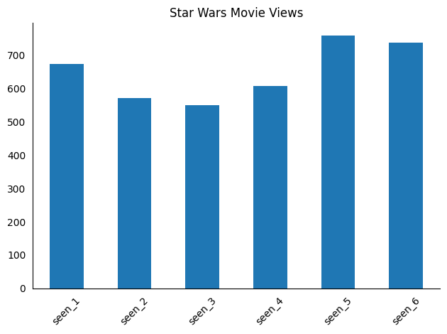

```python
# Plot views on a bar graph

seen_cols = ['seen_1', 'seen_2', 'seen_3', 'seen_4', 'seen_5', 'seen_6']

star_wars[seen_cols].sum().plot.bar()

plt.title('Star Wars Movie Views')

plt.xticks(rotation=45)

plt.tick_params(bottom=False, left=False)

plt.tight_layout()
sns.despine()

plt.savefig('visualizations/movie_views')
```

## Findings:

- The overall bar graph closely resembles the pattern within the 'rankings' bar graph
- Supports the insights that the original trilogy is more favored
- Suggests that people who favor a certain movie are likely to watch it more times than unfavored movies

# Exploring by Fandom

```python
# Melt the dataframe to get it in the right format for seaborn

fandom_col = 'Do you consider yourself to be a fan of the Star Wars film franchise?'

melted_df_ranking = star_wars[ranking_cols_new + [fandom_col]].melt(
    id_vars=[fandom_col], value_vars=ranking_cols_new, var_name='movie', value_name='ranking'
)
```

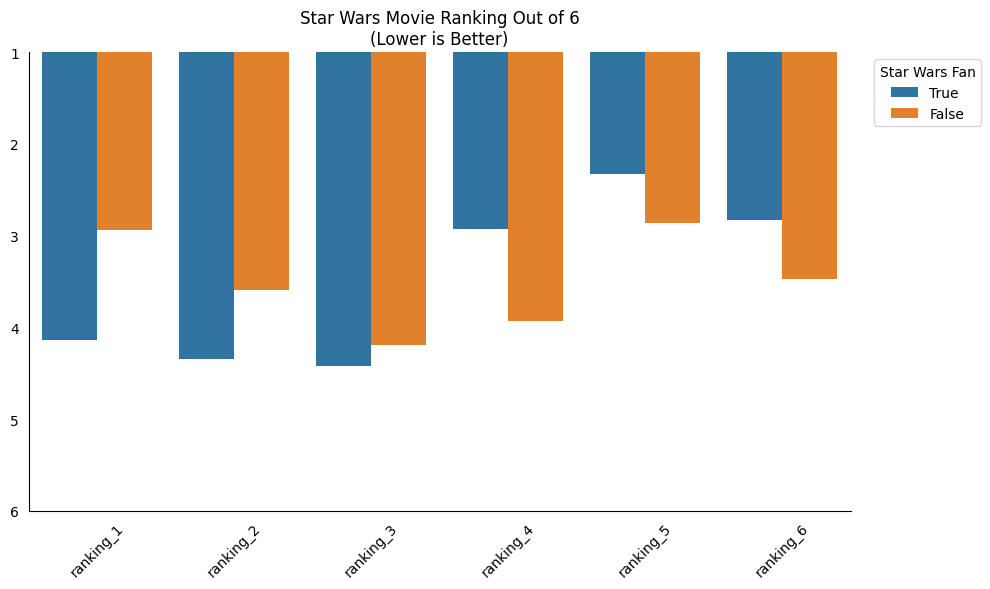

```python
# Plot rankings on a bar graph per fandom (True/False)

plt.figure(figsize=(10, 6))
sns.barplot(data=melted_df_ranking, x='movie', y='ranking', hue=fandom_col, errorbar=('ci', False))

plt.legend(bbox_to_anchor=(1.02, 1), title='Star Wars Fan')

plt.title('Star Wars Movie Ranking Out of 6\n(Lower is Better)')

plt.xlabel('')
plt.xticks(rotation=45)

plt.ylabel('')
plt.ylim(6, 1)

plt.tick_params(bottom=False, left=False)

plt.tight_layout()
sns.despine()

plt.savefig('visualizations/movie_rankings_per_fandom')
```

```python
# Melt the dataframe to get it in the right format for seaborn

fandom_col = 'Do you consider yourself to be a fan of the Star Wars film franchise?'

melted_df_seen = star_wars[seen_cols + [fandom_col]].melt(
    id_vars=[fandom_col], value_vars=seen_cols, var_name='movie', value_name='seen'
)
```

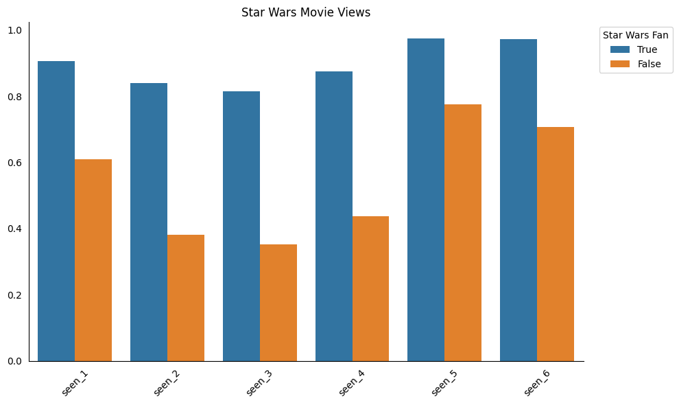

```python
# Plot views on a bar graph per fandom (True/False)

plt.figure(figsize=(10, 6))
sns.barplot(data=melted_df_seen, x='movie', y='seen', hue=fandom_col, errorbar=('ci', False))

plt.legend(bbox_to_anchor=(1.02, 1), title='Star Wars Fan')

plt.title('Star Wars Movie Views')

plt.xlabel('')
plt.xticks(rotation=45)

plt.ylabel('')

plt.tick_params(bottom=False, left=False)

plt.tight_layout()
sns.despine()

plt.savefig('visualizations/movie_views_per_fandom')
```

## Findings:

- Non Star Wars fans prefer Episode I over Episode IV in rankings compared to Star Wars fans
- Overall rankings are similar, where the original trilogy scores better
- Pattern in movie view counts are similar between fans and non-fans
- Non-fans have a higher range on whether they've seen a movie (which makes sense as fans are more likely to give the whole series a shot)